# Multivariate GLM

Kate Culhane

## Moran’s Eigenvector Maps (MEM)

**Purpose:** Create spatial filters that remove the spatial autocorrelation from the residuals of the community structure GLMs to meet assumption of independence

**Resources for MEM analysis:**

- [Bauman et al. 2018:](https://doi.org/10.1002/ecy.2469) Optimizing the choice of a spatial weighting matrix in eigenvector-based methods
- [Bauman et al. 2018, Appendix S3:](https://esajournals.onlinelibrary.wiley.com/action/downloadSupplement?doi=10.1002%2Fecy.2469&file=ecy2469-sup-0003-AppendixS3.pdf) Tutorial to optimize the selection of a spatial weighting matrix and/or the selection of a subset of spatial predictors in eigenvector-mapping methods

**Spatial weighting matrix (SWM)**

- Describes the relations among a set of sampled sites
- Calculated as the element-wise product of a connectivity matrix (B) and weighting matrix (A)
- *Connectivity matrix (B)*
  - Graph-based methods: Delaunay triangulation, Gabriel’s graph, Relative neighbourhood graph, Minimum spanning tree
  - Distance based methods: Principal Coordinates of Neighbour Matrices (PCNM)
- *Weighting matrix (A)*

**SWM selection**

1. Determine candidate matrix B
- Visualize the connection scheme and compare to realistic landscape connectivity
- *Considering that it’s highly unlikely that smamms traveled between the farthest sites (or across the river), we ruled out Delauney triangulation*
2. Determine candidate matrix A
- View plot connectivity vs. distance with different functions (see Bauman et al. 2018, Appendix S1, Fig. S2)
- *We chose a weighting matrix that uses a linear function to indicate that connectivity with distance (smamms are less likely to travel between distant sites); see Dray et al. 2006*
- *The PCNM method does not incorporate weighting matrix, so we also included weights = ‘binary’ option*
3. Select a candidate using forward selection with model residuals
- Goal: Optimize the selection of the spatial variables unexplained by severity
- Multivariate data requires use of forward selection
- *We used residuals from a multivariate GLM (spp abundances ~ severity)*

```
##                      R2Adj    Pvalue N.var R2Adj.select
## DBEM_PCNM       0.05939967 0.5257802    NA           NA
## Gabriel_Binary  0.04944730 0.8913144    NA           NA
## Gabriel_Linear  0.03391034 0.9545560    NA           NA
## Relative_Binary 0.05460129 0.8618377    NA           NA
## Relative_Linear 0.01403845 0.9794452    NA           NA
## MST_Binary      0.05418374 0.8192373    NA           NA
## MST_Linear      0.06073530 0.7494349    NA           NA
```

```
## [1] "Seed = 1: NONE SIGNIFICANT"
## [1] "Seed = 2: NONE SIGNIFICANT"
## [1] "Seed = 3: NONE SIGNIFICANT"
## [1] "Seed = 4: NONE SIGNIFICANT"
## [1] "Seed = 5: NONE SIGNIFICANT"
## [1] "Seed = 6: NONE SIGNIFICANT"
## [1] "Seed = 7: NONE SIGNIFICANT"
## [1] "Seed = 8: NONE SIGNIFICANT"
## [1] "Seed = 9: NONE SIGNIFICANT"
## [1] "Seed = 10: NONE SIGNIFICANT"
## [1] "Seed = 11: NONE SIGNIFICANT"
## [1] "Seed = 12: NONE SIGNIFICANT"
## [1] "Seed = 13: NONE SIGNIFICANT"
## [1] "Seed = 14: NONE SIGNIFICANT"
## [1] "Seed = 15: NONE SIGNIFICANT"
```

[output cut: 35 more lines]

## Multivariate GLMs

Resources for `mvabund`:

- [Introduction from Warton](http://eco-stats.blogspot.com/2012/03/introducing-mvabund-package-and-why.html)
- [Tutorial](https://www.dropbox.com/s/unwd412a9wbkrl0/mvabundTute.R?dl=0)
- [Powerpoint about mvabund](http://www.seec.uct.ac.za/sites/default/files/image_tool/images/330/SEEC%20Toolbox%20mvabund.pdf) (video lecture is also useful)
- [Differences between `anova` and `summary`](https://stats.stackexchange.com/questions/59879/logistic-regression-anova-chi-square-test-vs-significance-of-coefficients-ano)
- [Wald vs. score test statistic](https://stats.idre.ucla.edu/other/mult-pkg/faq/general/faqhow-are-the-likelihood-ratio-wald-and-lagrange-multiplier-score-tests-different-andor-similar/)
- [Introduction to trait analysis by Warton](https://rpubs.com/dwarton/68823)

## GLM<sub>severity</sub>

*Does treatment have an effect on assemblage?*

Testing for differences in multivariate community structure among the three fire severity categories

### Model

- **Predictors:** severity
- **Responses:** absolute abundances (`anova.manyglm` can’t handle relative abundance)
  - Trapping effort accounted for with an offset
  - Assumes negative binomial distribution

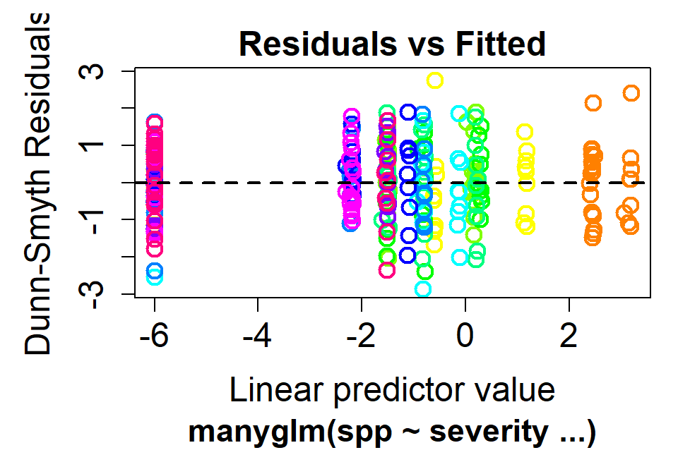

```r
glm_sev <- manyglm(data=dat, spp ~ severity,
                   composition=FALSE, # anova function (next) can't handle relative abundance
                   offset=effort$offset, # accounts for trapping effort
                   family='negative_binomial') # accounts for observed mean-variance relationship

plot(glm_sev) # check for model fit
```

### Significance (multivariate & univariate)

- `anova.manyglm` determines which predictors are the strongest contributors by sequentially adding them to the restricted (less variables) model (for test=score)
  - Used the score test to calculate test statistics since means are small because of rare species (small means decrease power when using the Wald test)
  - Accounted for correlation between variables by shrinking the correlation matrix
  - Calculated p-values using PIT-trap resampling with 999 bootstrap samples
  - Calculated p-values for both multivariate and univariate (species-specific) responses

```r
set.seed(2021)
an_sev <- anova(glm_sev,
                test='score', # allows for small means due to rare species
                cor.type='shrink', # accounts for correlation between variables
                resamp='pit.trap', # p-value calculated via PIT-trap resampling
                nBoot=999, # number of PIT-trap bootstrap iterations
                p.uni='adjusted') # also calculate univariate p-values
```

```
## Time elapsed: 0 hr 0 min 3 sec
```

```r
an_sev
```

```
## Analysis of Variance Table
##
## Model: spp ~ severity
##
## Multivariate test:
##             Res.Df Df.diff score Pr(>score)
## (Intercept)     26
## severity        24       2  31.5      0.004 **
## ---
## Signif. codes:  0 '***' 0.001 '**' 0.01 '*' 0.05 '.' 0.1 ' ' 1
##
## Univariate Tests:
##              GLSA             NEAM             NEFU             NEQU             NESE             OTBE
##             score Pr(>score) score Pr(>score) score Pr(>score) score Pr(>score) score Pr(>score) score Pr(>score)
## (Intercept)
## severity    3.932      0.401 1.068      0.908 2.238      0.773 1.615      0.908 1.979      0.885 1.547      0.908
##              PEBO              PEMA             PETR             REME             SOTR
##             score Pr(>score)  score Pr(>score) score Pr(>score) score Pr(>score) score Pr(>score)
## (Intercept)
## severity     3.59      0.448 11.413      0.005 1.001      0.908 1.205      0.908 9.797      0.005
## Arguments:
##  Test statistics calculated assuming correlated response via ridge regularization
## P-value calculated using 999 iterations via PIT-trap resampling.
```

## GLM<sub>veg</sub>

*Which environmental variables are most strongly associated with assemblages?*

Testing for differences in multivariate small mammal community structure according to the vegetation variables

### AIC model selection

**Candidate predictors:**

- PC1<sub>TSL</sub> (Live tree density + Shrub cover + Litter cover)
- Soft coarse woody debris (CWD)
- Forb/grass cover

```
##                                             vars k    aic delta_aic weight
## 1                    pca_score + soft_cwd_volume 2 583.37      0.00   0.98
## 2 pca_score + forb_grass_cover + soft_cwd_volume 3 591.16      7.79   0.02
## 3                                      pca_score 1 598.93     15.56   0.00
## 4                   pca_score + forb_grass_cover 2 605.05     21.67   0.00
## 5                                soft_cwd_volume 1 612.52     29.14   0.00
## 6             forb_grass_cover + soft_cwd_volume 2 617.17     33.79   0.00
## 7                               forb_grass_cover 1 627.67     44.30   0.00
```

### Final model

- **Final predictors:** PC1<sub>TSL</sub> + Soft CWD
- **Responses:** absolute abundances
  - Trapping effort accounted for with an offset
  - Assumes negative binomial distribution

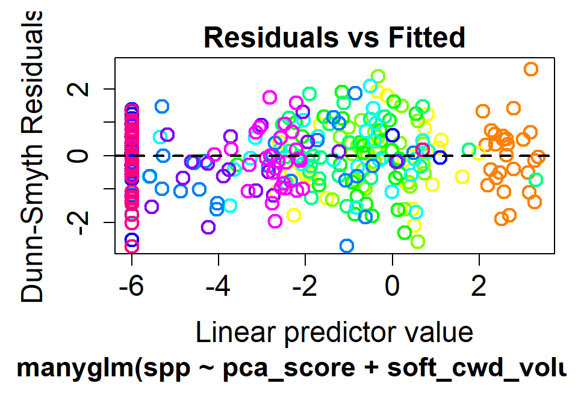

```r
glm_veg <- manyglm(data=dat, spp ~ pca_score + soft_cwd_volume,
                   composition=FALSE, # absolute abundance
                   offset=effort$offset, # trapping effort
                   family='negative_binomial') # data distribution

plot(glm_veg) # check for model fit
```

### Significance

- `summary` determines which predictors are the strongest contributors when all other predictors have been fitted to the restricted (less variables) model (true for for test=score)
  - Used the score test to calculate test statistics
  - Accounted for correlation between variables by shrinking the correlation matrix
  - Calculated p-values using PIT-trap resampling with 999 bootstrap samples

```r
set.seed(2021)
sum_veg <- summary(glm_veg,
                   test='score', # allows for small means due to rare species
                   cor.type='shrink', # accounts for correlation between variables
                   resamp='pit.trap', # p-value calculated via PIT-trap resampling
                   nBoot=999) # number of PIT-trap bootstrap iterations
sum_veg
```

```
##
## Test statistics:
##                 score value Pr(>score)
## (Intercept)           90.94      0.001 ***
## pca_score             30.82      0.001 ***
## soft_cwd_volume       16.50      0.023 *
## ---
## Signif. codes:  0 '***' 0.001 '**' 0.01 '*' 0.05 '.' 0.1 ' ' 1
##
## Test statistic:  37.85, p-value: 0.002
## Arguments:
##  Test statistics calculated assuming correlation matrix shrunk by parameter 0.34
##  P-value calculated using 999 resampling iterations via pit.trap resampling (to account for correlation in testing).
```

## GLM<sub>trait</sub>

Fourth-corner analysis (trait by environment interactions)

### Model

- **Predictors:** interactions between vegetation variables (PC1<sub>TSL</sub> + Soft CWD) and small mammal traits (feeding guild + foraging mode + nesting habit)
- **Responses:** relative small mammal abundances
  - No option for including an offset to account for trapping effort, so used relative abundance data instead
  - Using relative instead of absolute abundance improved model fit by decreasing heteroscedasticity of residuals
  - Assumes negative binomial distribution

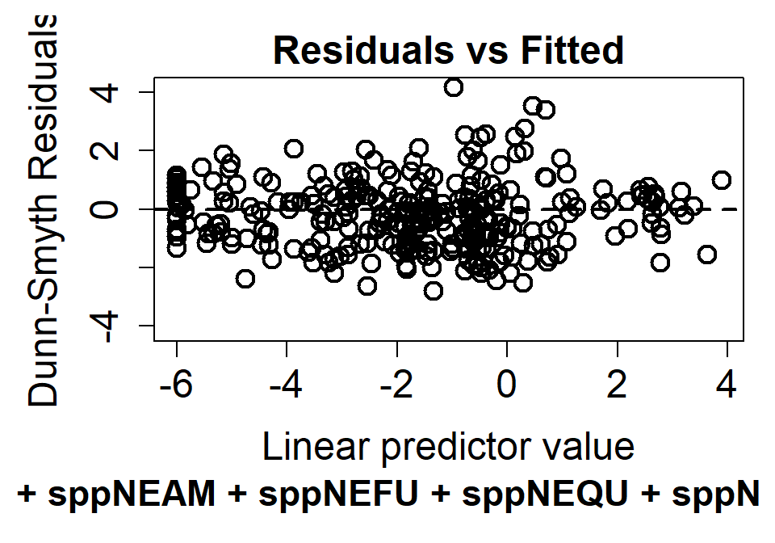

```r
glm_trait <- traitglm(L_dat, R_dat[-1], Q_dat[-1],
                      composition=TRUE, # relative abundance
                      method='manyglm',
                      family='negative.binomial') # accounts for mean-variance relationship

plot(glm_trait) # check for model fit
```

### Significance

- `anova` tests whether the environment-trait interactions predict community structure
  - Used the score test to calculate test statistics
  - No need to shrink the correlation matrix
  - Calculated p-values using PIT-trap resampling with 999 bootstrap samples

```r
set.seed(2021)
an_trait <- anova(glm_trait,
                  test='score', # allows for small means due to rare species
                  resamp='pit.trap', # p-value calculated via PIT-trap resampling
                  nBoot=999) # number of PIT-trap bootstrap iterations
```

```
## Using block resampling...
## Resampling begins for test 1.
##  Resampling run 0 finished. Time elapsed: 0.00 minutes...
##  Resampling run 100 finished. Time elapsed: 0.06 minutes...
##  Resampling run 200 finished. Time elapsed: 0.11 minutes...
##  Resampling run 300 finished. Time elapsed: 0.15 minutes...
##  Resampling run 400 finished. Time elapsed: 0.20 minutes...
##  Resampling run 500 finished. Time elapsed: 0.25 minutes...
##  Resampling run 600 finished. Time elapsed: 0.30 minutes...
##  Resampling run 700 finished. Time elapsed: 0.35 minutes...
##  Resampling run 800 finished. Time elapsed: 0.40 minutes...
##  Resampling run 900 finished. Time elapsed: 0.45 minutes...
## Time elapsed: 0 hr 0 min 30 sec
```

```r
an_trait$table
```

```
##                           Res.Df Df.diff    score Pr(>score)
## Main effects only            260      NA       NA         NA
## env:trait (fourth corner)    248      12 59.17501      0.008
```

### LASSO penalty model selection

- Uses the LASSO penalty to do model selection (removes interaction terms that do not decrease BIC)
- Cannot use `anova` with this method
- Shows which environment-trait interactions are most important for determining community structure

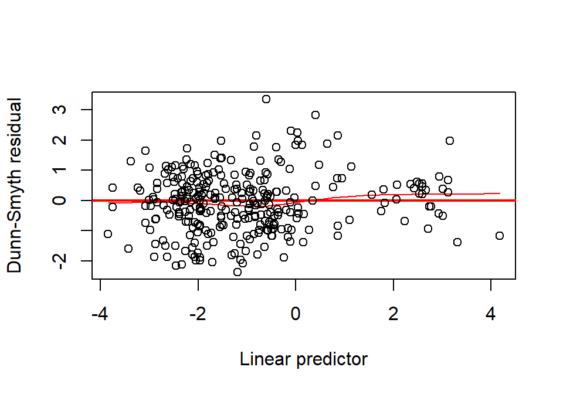

```r
# LASSO penalty
set.seed(2021)
glm_fc <- traitglm(L_dat, R_dat[-1], Q_dat[-1],
                   composition=TRUE, # relative abundance
                   method='glm1path', # LASSO penalty
                   family='negative.binomial') # accounts for mean-variance relationship

plot(glm_fc) # check model fit
```

### Heat map

Trait-environment interaction coefficient estimates

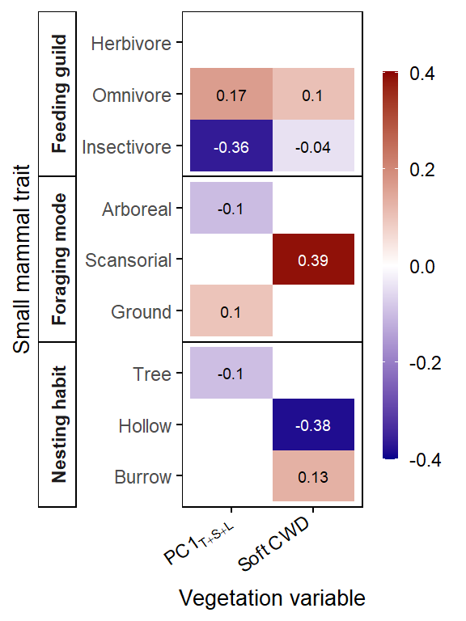